# Association Rules

16th September 2017

**NOTE** Before starting this assignment please remember to clear your environment, you can do that by running the following code chunk

```r
rm(list=ls(all=TRUE))
```

# Agenda

- Getting the data and pre-processing it into a suitable format
- Exploring the transaction data
- Applying Apriori algoirhtm on transaction data
- Getting frequent itemsets and rules
- Inspecting and summarizing rules
- Picking rules based on support and confidence
- Picking rules with desired RHS or LHS / rule length, by subsetting the rules
- Plotting and visualizaing the itemsets and rules

## Requisites for working with Arules in R

- Association rule mining can only use items and does not work with continuous variables
- Apriori function of Arules package works with Formal tansactions class, and hence data should be formatted properly before reading it in as transaction data

# Problem 1

## Assoiction rule mining on Unsupervised dataset

### Problem Description

- The transaction data at a retail Point of sales system is given, with transaction ID and item bought in each transaction. We inspect the data and apply apriori method to find frequent itemsets and association rules hidden in the transactions.

## Load the required “arules” package

```r
library(arules)
```

## Read ‘Transactions.csv’ file using read.transactions function.

```r
setwd("E:\\INSOFE_CPEE\\Assignments")
trans = read.transactions(file="Transactions.csv",rm.duplicates=FALSE, format="single",sep=",", cols=c(1,2))
```

## Explore the understand the transaction data

### Print and understand the transaction data

```r
summary(trans)
```

```
transactions as itemMatrix in sparse format with
 10 rows (elements/itemsets/transactions) and
 6 columns (items) and a density of 0.3833333

most frequent items:
   Pencil Choclates    Marker      Coke   Cookies   (Other)
        8         5         5         2         2         1

element (itemset/transaction) length distribution:
sizes
1 2 3
1 5 4

   Min. 1st Qu.  Median    Mean 3rd Qu.    Max.
    1.0     2.0     2.0     2.3     3.0     3.0

includes extended item information - examples:
     labels
1 Choclates
2      Coke
3   Cookies

includes extended transaction information - examples:
  transactionID
1          1001
2          1002
3          1003
```

### Explore the transaction data using inspect function

```r
inspect(trans)
```

```
     items                      transactionID
[1]  {Choclates,Marker,Pencil}  1001
[2]  {Choclates,Pencil}         1002
[3]  {Coke,Eraser,Pencil}       1003
[4]  {Choclates,Cookies,Pencil} 1004
[5]  {Marker}                   1005
[6]  {Marker,Pencil}            1006
[7]  {Choclates,Pencil}         1007
[8]  {Choclates,Cookies,Pencil} 1008
[9]  {Marker,Pencil}            1009
[10] {Coke,Marker}              1010
```

### Plotting the transaction data using image function.

- Note: This works only for smaller datasets
- Items numbers are provied and items are sorted in alphabetical order

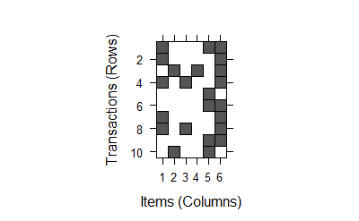

### Find the item frequency using itemFrequency function

```r
itemFrequency(trans)
```

```
Choclates      Coke   Cookies    Eraser    Marker    Pencil
      0.5       0.2       0.2       0.1       0.5       0.8
```

### Plot item frequency

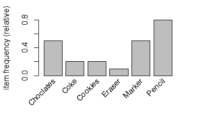

## Applying Apriori algorithm on the data

### Interested only in those rules that have min sup of 0.2 and conf of 0.6

```r
rules = apriori(trans, parameter=list(sup=0.2, conf=0.6, target="rules"))
```

```
Apriori

Parameter specification:
 confidence minval smax arem  aval originalSupport maxtime support minlen maxlen target   ext
        0.6    0.1    1 none FALSE            TRUE       5     0.2      1     10  rules FALSE

Algorithmic control:
 filter tree heap memopt load sort verbose
    0.1 TRUE TRUE  FALSE TRUE    2    TRUE

Absolute minimum support count: 2

set item appearances ...[0 item(s)] done [0.00s].
set transactions ...[6 item(s), 10 transaction(s)] done [0.00s].
sorting and recoding items ... [5 item(s)] done [0.00s].
creating transaction tree ... done [0.00s].
checking subsets of size 1 2 3 done [0.00s].
writing ... [8 rule(s)] done [0.00s].
creating S4 object  ... done [0.00s].
```

### Inspect the rules using inpsect function

```r
inspect(rules)
```

```
    lhs                    rhs         support confidence lift
[1] {}                  => {Pencil}    0.8     0.800      1.00
[2] {Cookies}           => {Choclates} 0.2     1.000      2.00
[3] {Cookies}           => {Pencil}    0.2     1.000      1.25
[4] {Marker}            => {Pencil}    0.3     0.600      0.75
[5] {Choclates}         => {Pencil}    0.5     1.000      1.25
[6] {Pencil}            => {Choclates} 0.5     0.625      1.25
[7] {Choclates,Cookies} => {Pencil}    0.2     1.000      1.25
[8] {Cookies,Pencil}    => {Choclates} 0.2     1.000      2.00
```

### Visualizng the rules

[output not shown]

[output not shown]

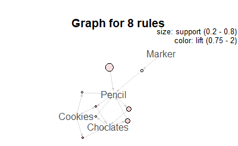

```r
library(arulesViz)
plot(rules, method="graph", control=list(type="items"))
```

## Rules

### Print top 5 rules, sorted by confidence and then support

```r
top_rules = sort(rules, by = c("confidence", "support"))
head(as(top_rules, "data.frame"), n=5)
```

|  | rules | support | confidence | lift |
| --- | --- | --- | --- | --- |
| 5 | {Choclates} => {Pencil} | 0.5 | 1 | 1.25 |
| 2 | {Cookies} => {Choclates} | 0.2 | 1 | 2.00 |
| 3 | {Cookies} => {Pencil} | 0.2 | 1 | 1.25 |
| 7 | {Choclates,Cookies} => {Pencil} | 0.2 | 1 | 1.25 |
| 8 | {Cookies,Pencil} => {Choclates} | 0.2 | 1 | 2.00 |

### Subset the rules based on LHS/RHS

```r
rules.itemfilter1 <- as(subset(rules, subset = rhs %in%
                        "Choclates"),
                        "data.frame")
rules.itemfilter1
```

|  | rules | support | confidence | lift |
| --- | --- | --- | --- | --- |
| 2 | {Cookies} => {Choclates} | 0.2 | 1.000 | 2.00 |
| 6 | {Pencil} => {Choclates} | 0.5 | 0.625 | 1.25 |
| 8 | {Cookies,Pencil} => {Choclates} | 0.2 | 1.000 | 2.00 |

```r
rules.itemfilter2 <- as(subset(rules, subset = lhs %in%
                        "Pencil"),
                        "data.frame")
rules.itemfilter2
```

|  | rules | support | confidence | lift |
| --- | --- | --- | --- | --- |
| 6 | {Pencil} => {Choclates} | 0.5 | 0.625 | 1.25 |
| 8 | {Cookies,Pencil} => {Choclates} | 0.2 | 1.000 | 2.00 |

### Picking a subset of rules based on a given range of a quality measure

```r
rules_Lift <- as(subset(rules, subset = rhs %in% "Pencil" & lift > 1.01),"data.frame")
rules_Lift
```

|  | rules | support | confidence | lift |
| --- | --- | --- | --- | --- |
| 3 | {Cookies} => {Pencil} | 0.2 | 1 | 1.25 |
| 5 | {Choclates} => {Pencil} | 0.5 | 1 | 1.25 |
| 7 | {Choclates,Cookies} => {Pencil} | 0.2 | 1 | 1.25 |

# Problem 2 - Assoiction rule mining on Supervised dataset

## Clean the global environment

```r
rm(list=ls(all=TRUE))
```

## Read in the titanic survival data set

```r
titanic_data <- read.csv(file = "titanic_data.csv")
```

### Explore the understant the data

```r
summary(titanic_data)
```

```
  Class         Sex          Age       Survived
 1st :325   Female: 470   Adult:2092   No :1490
 2nd :285   Male  :1731   Child: 109   Yes: 711
 3rd :706
 Crew:885
```

```r
head(titanic_data)
```

|  | Class | Sex | Age | Survived |
| --- | --- | --- | --- | --- |
| 1 | 3rd | Male | Child | No |
| 2 | 3rd | Male | Child | No |
| 3 | 3rd | Male | Child | No |
| 4 | 3rd | Male | Child | No |
| 5 | 3rd | Male | Child | No |
| 6 | 3rd | Male | Child | No |

### Apply Apriori on the data to find associations amongst all the attributes

```r
rules = apriori(data = titanic_data)
```

```
Apriori

Parameter specification:
 confidence minval smax arem  aval originalSupport maxtime support minlen maxlen target   ext
        0.8    0.1    1 none FALSE            TRUE       5     0.1      1     10  rules FALSE

Algorithmic control:
 filter tree heap memopt load sort verbose
    0.1 TRUE TRUE  FALSE TRUE    2    TRUE

Absolute minimum support count: 220

set item appearances ...[0 item(s)] done [0.00s].
set transactions ...[10 item(s), 2201 transaction(s)] done [0.00s].
sorting and recoding items ... [9 item(s)] done [0.00s].
creating transaction tree ... done [0.00s].
checking subsets of size 1 2 3 4 done [0.00s].
writing ... [27 rule(s)] done [0.00s].
creating S4 object  ... done [0.00s].
```

### Inspect the rules

```r
inspect(rules)
```

```
     lhs                                   rhs           support   confidence lift
[1]  {}                                 => {Age=Adult}   0.9504771 0.9504771  1.0000000
[2]  {Class=2nd}                        => {Age=Adult}   0.1185825 0.9157895  0.9635051
[3]  {Class=1st}                        => {Age=Adult}   0.1449341 0.9815385  1.0326798
[4]  {Sex=Female}                       => {Age=Adult}   0.1930940 0.9042553  0.9513700
[5]  {Class=3rd}                        => {Age=Adult}   0.2848705 0.8881020  0.9343750
[6]  {Survived=Yes}                     => {Age=Adult}   0.2971377 0.9198312  0.9677574
[7]  {Class=Crew}                       => {Sex=Male}    0.3916402 0.9740113  1.2384742
[8]  {Class=Crew}                       => {Age=Adult}   0.4020900 1.0000000  1.0521033
[9]  {Survived=No}                      => {Sex=Male}    0.6197183 0.9154362  1.1639949
[10] {Survived=No}                      => {Age=Adult}   0.6533394 0.9651007  1.0153856
[11] {Sex=Male}                         => {Age=Adult}   0.7573830 0.9630272  1.0132040
[12] {Sex=Female,Survived=Yes}          => {Age=Adult}   0.1435711 0.9186047  0.9664669
[13] {Class=3rd,Sex=Male}               => {Survived=No} 0.1917310 0.8274510  1.2222950
[14] {Class=3rd,Survived=No}            => {Age=Adult}   0.2162653 0.9015152  0.9484870
[15] {Class=3rd,Sex=Male}               => {Age=Adult}   0.2099046 0.9058824  0.9530818
[16] {Sex=Male,Survived=Yes}            => {Age=Adult}   0.1535666 0.9209809  0.9689670
[17] {Class=Crew,Survived=No}           => {Sex=Male}    0.3044071 0.9955423  1.2658514
[18] {Class=Crew,Survived=No}           => {Age=Adult}   0.3057701 1.0000000  1.0521033
[19] {Class=Crew,Sex=Male}              => {Age=Adult}   0.3916402 1.0000000  1.0521033
[20] {Class=Crew,Age=Adult}             => {Sex=Male}    0.3916402 0.9740113  1.2384742
[21] {Sex=Male,Survived=No}             => {Age=Adult}   0.6038164 0.9743402  1.0251065
[22] {Age=Adult,Survived=No}            => {Sex=Male}    0.6038164 0.9242003  1.1751385
[23] {Class=3rd,Sex=Male,Survived=No}   => {Age=Adult}   0.1758292 0.9170616  0.9648435
[24] {Class=3rd,Age=Adult,Survived=No}  => {Sex=Male}    0.1758292 0.8130252  1.0337773
[25] {Class=3rd,Sex=Male,Age=Adult}     => {Survived=No} 0.1758292 0.8376623  1.2373791
[26] {Class=Crew,Sex=Male,Survived=No}  => {Age=Adult}   0.3044071 1.0000000  1.0521033
[27] {Class=Crew,Age=Adult,Survived=No} => {Sex=Male}    0.3044071 0.9955423  1.2658514
```

### Rules with rhs containing target attribute

```r
rules = apriori(titanic_data,
                parameter=list(minlen=2, supp=0.005, conf=0.8),
                appearance=list(rhs=c("Survived=No", "Survived=Yes"),
                                default="lhs"))
```

```
Apriori

Parameter specification:
 confidence minval smax arem  aval originalSupport maxtime support minlen maxlen target   ext
        0.8    0.1    1 none FALSE            TRUE       5   0.005      2     10  rules FALSE

Algorithmic control:
 filter tree heap memopt load sort verbose
    0.1 TRUE TRUE  FALSE TRUE    2    TRUE

Absolute minimum support count: 11

set item appearances ...[2 item(s)] done [0.00s].
set transactions ...[10 item(s), 2201 transaction(s)] done [0.00s].
sorting and recoding items ... [10 item(s)] done [0.00s].
creating transaction tree ... done [0.00s].
checking subsets of size 1 2 3 4 done [0.00s].
writing ... [12 rule(s)] done [0.00s].
creating S4 object  ... done [0.00s].
```

### Inspect the rules

```r
inspect(rules)
```

```
     lhs                                  rhs            support     confidence lift
[1]  {Class=2nd,Age=Child}             => {Survived=Yes} 0.010904134 1.0000000  3.095640
[2]  {Class=2nd,Sex=Female}            => {Survived=Yes} 0.042253521 0.8773585  2.715986
[3]  {Class=2nd,Sex=Male}              => {Survived=No}  0.069968196 0.8603352  1.270871
[4]  {Class=1st,Sex=Female}            => {Survived=Yes} 0.064061790 0.9724138  3.010243
[5]  {Class=Crew,Sex=Female}           => {Survived=Yes} 0.009086779 0.8695652  2.691861
[6]  {Class=3rd,Sex=Male}              => {Survived=No}  0.191731031 0.8274510  1.222295
[7]  {Class=2nd,Sex=Female,Age=Child}  => {Survived=Yes} 0.005906406 1.0000000  3.095640
[8]  {Class=2nd,Sex=Female,Age=Adult}  => {Survived=Yes} 0.036347115 0.8602151  2.662916
[9]  {Class=2nd,Sex=Male,Age=Adult}    => {Survived=No}  0.069968196 0.9166667  1.354083
[10] {Class=1st,Sex=Female,Age=Adult}  => {Survived=Yes} 0.063607451 0.9722222  3.009650
[11] {Class=Crew,Sex=Female,Age=Adult} => {Survived=Yes} 0.009086779 0.8695652  2.691861
[12] {Class=3rd,Sex=Male,Age=Adult}    => {Survived=No}  0.175829169 0.8376623  1.237379
```

### Sort the rules based on “lift” and inspect

```r
rules.sorted = sort(rules, by="lift")
inspect(rules.sorted)
```

```
     lhs                                  rhs            support     confidence lift
[1]  {Class=2nd,Age=Child}             => {Survived=Yes} 0.010904134 1.0000000  3.095640
[2]  {Class=2nd,Sex=Female,Age=Child}  => {Survived=Yes} 0.005906406 1.0000000  3.095640
[3]  {Class=1st,Sex=Female}            => {Survived=Yes} 0.064061790 0.9724138  3.010243
[4]  {Class=1st,Sex=Female,Age=Adult}  => {Survived=Yes} 0.063607451 0.9722222  3.009650
[5]  {Class=2nd,Sex=Female}            => {Survived=Yes} 0.042253521 0.8773585  2.715986
[6]  {Class=Crew,Sex=Female}           => {Survived=Yes} 0.009086779 0.8695652  2.691861
[7]  {Class=Crew,Sex=Female,Age=Adult} => {Survived=Yes} 0.009086779 0.8695652  2.691861
[8]  {Class=2nd,Sex=Female,Age=Adult}  => {Survived=Yes} 0.036347115 0.8602151  2.662916
[9]  {Class=2nd,Sex=Male,Age=Adult}    => {Survived=No}  0.069968196 0.9166667  1.354083
[10] {Class=2nd,Sex=Male}              => {Survived=No}  0.069968196 0.8603352  1.270871
[11] {Class=3rd,Sex=Male,Age=Adult}    => {Survived=No}  0.175829169 0.8376623  1.237379
[12] {Class=3rd,Sex=Male}              => {Survived=No}  0.191731031 0.8274510  1.222295
```

## Observation: Redundant Rules

- Rule #2 provides no extra knowledge in addition to rule #1, since rules #1 tells us that all 2nd-class children survived.
- When a rule (such as #2) is a super rule of another rule (#1) and the former has the same or a lower lift, the former rule (#2) is considered to be redundant. ## Other redundant rules in the above result are rules #4, #7 and #8, compared respectively with #3, #6 and #5.

```r
## find redundant rules
subset.matrix = as.matrix(is.subset(rules.sorted, rules.sorted))
subset.matrix[lower.tri(subset.matrix, diag = T)] <- NA
redundant <- colSums(subset.matrix, na.rm = T) >= 1
## which rules are redundant
which(redundant)
```

```
 {Class=2nd,Sex=Female,Age=Child,Survived=Yes}  {Class=1st,Sex=Female,Age=Adult,Survived=Yes}
                                             2                                              4
{Class=Crew,Sex=Female,Age=Adult,Survived=Yes}  {Class=2nd,Sex=Female,Age=Adult,Survived=Yes}
                                             7                                              8
```

### Removing redundant rules

```r
rules.pruned <- rules.sorted[!redundant]
inspect(rules.pruned)
```

```
    lhs                               rhs            support     confidence lift
[1] {Class=2nd,Age=Child}          => {Survived=Yes} 0.010904134 1.0000000  3.095640
[2] {Class=1st,Sex=Female}         => {Survived=Yes} 0.064061790 0.9724138  3.010243
[3] {Class=2nd,Sex=Female}         => {Survived=Yes} 0.042253521 0.8773585  2.715986
[4] {Class=Crew,Sex=Female}        => {Survived=Yes} 0.009086779 0.8695652  2.691861
[5] {Class=2nd,Sex=Male,Age=Adult} => {Survived=No}  0.069968196 0.9166667  1.354083
[6] {Class=2nd,Sex=Male}           => {Survived=No}  0.069968196 0.8603352  1.270871
[7] {Class=3rd,Sex=Male,Age=Adult} => {Survived=No}  0.175829169 0.8376623  1.237379
[8] {Class=3rd,Sex=Male}           => {Survived=No}  0.191731031 0.8274510  1.222295
```

# Problem 3 - Assignment

### Association Rules for “Flight Delay” dataset: Generate the rules and identify the patterns.

1. Read the data into R
2. Look at the summary of all the variables and convert the following variables as factors + Weather + DAY_WEEK + Flight Status

```r
data = read.csv("FlightDelays.csv",header =T)
summary(data)
```

```
  CRS_DEP_TIME     CARRIER     DEST      ORIGIN        Weather           DAY_WEEK
 Min.   : 600   DH     :551   EWR: 665   BWI: 145   Min.   :0.00000   Min.   :1.000
 1st Qu.:1000   RU     :408   JFK: 386   DCA:1370   1st Qu.:0.00000   1st Qu.:2.000
 Median :1455   US     :404   LGA:1150   IAD: 686   Median :0.00000   Median :4.000
 Mean   :1372   DL     :388                         Mean   :0.01454   Mean   :3.905
 3rd Qu.:1710   MQ     :295                         3rd Qu.:0.00000   3rd Qu.:5.000
 Max.   :2130   CO     : 94                         Max.   :1.00000   Max.   :7.000
                (Other): 61
 Flight.Status
 Min.   :0.0000
 1st Qu.:0.0000
 Median :0.0000
 Mean   :0.1945
 3rd Qu.:0.0000
 Max.   :1.0000
```

```r
str(data)
```

```
'data.frame':   2201 obs. of  7 variables:
 $ CRS_DEP_TIME : int  600 600 600 600 600 600 600 600 600 600 ...
 $ CARRIER      : Factor w/ 8 levels "CO","DH","DL",..: 4 4 4 4 4 4 4 4 4 4 ...
 $ DEST         : Factor w/ 3 levels "EWR","JFK","LGA": 2 2 2 2 2 2 2 2 2 2 ...
 $ ORIGIN       : Factor w/ 3 levels "BWI","DCA","IAD": 2 2 2 2 2 2 2 2 2 2 ...
 $ Weather      : int  0 0 0 0 0 0 0 0 0 0 ...
 $ DAY_WEEK     : int  4 5 6 7 1 2 3 4 5 6 ...
 $ Flight.Status: int  0 0 0 0 0 0 0 0 0 1 ...
```

```r
data$Weather = as.factor(data$Weather)
data$DAY_WEEK = as.factor(data$DAY_WEEK)
data$Flight.Status = as.factor((data$Flight.Status))
str(data)
```

```
'data.frame':   2201 obs. of  7 variables:
 $ CRS_DEP_TIME : int  600 600 600 600 600 600 600 600 600 600 ...
 $ CARRIER      : Factor w/ 8 levels "CO","DH","DL",..: 4 4 4 4 4 4 4 4 4 4 ...
 $ DEST         : Factor w/ 3 levels "EWR","JFK","LGA": 2 2 2 2 2 2 2 2 2 2 ...
 $ ORIGIN       : Factor w/ 3 levels "BWI","DCA","IAD": 2 2 2 2 2 2 2 2 2 2 ...
 $ Weather      : Factor w/ 2 levels "0","1": 1 1 1 1 1 1 1 1 1 1 ...
 $ DAY_WEEK     : Factor w/ 7 levels "1","2","3","4",..: 4 5 6 7 1 2 3 4 5 6 ...
 $ Flight.Status: Factor w/ 2 levels "0","1": 1 1 1 1 1 1 1 1 1 2 ...
```

```r
bins = c(530,1130,1730,2400)
names = c("Morning","Noon","Forenoon")
data$CRS_DEP_TIME.cat = cut(data$CRS_DEP_TIME,breaks = bins,labels = names)
data
```

| CRS_DEP_TIME | CARRIER | DEST | ORIGIN | Weather | DAY_WEEK | Flight.Status | CRS_DEP_TIME.cat |
| --- | --- | --- | --- | --- | --- | --- | --- |
| 600 | MQ | JFK | DCA | 0 | 4 | 0 | Morning |
| 600 | MQ | JFK | DCA | 0 | 5 | 0 | Morning |
| 600 | MQ | JFK | DCA | 0 | 6 | 0 | Morning |
| 600 | MQ | JFK | DCA | 0 | 7 | 0 | Morning |
| 600 | MQ | JFK | DCA | 0 | 1 | 0 | Morning |
| 600 | MQ | JFK | DCA | 0 | 2 | 0 | Morning |
| 600 | MQ | JFK | DCA | 0 | 3 | 0 | Morning |
| 600 | MQ | JFK | DCA | 0 | 4 | 0 | Morning |
| 600 | MQ | JFK | DCA | 0 | 5 | 0 | Morning |
| 600 | MQ | JFK | DCA | 0 | 6 | 1 | Morning |

[output cut: 990 more lines]

```r
str(data_trans)
```

```
Formal class 'transactions' [package "arules"] with 3 slots
  ..@ data       :Formal class 'ngCMatrix' [package "Matrix"] with 5 slots
  .. .. ..@ i       : int [1:15407] 3 9 12 14 19 23 25 3 9 12 ...
  .. .. ..@ p       : int [1:2202] 0 7 14 21 28 35 42 49 56 63 ...
  .. .. ..@ Dim     : int [1:2] 28 2201
  .. .. ..@ Dimnames:List of 2
  .. .. .. ..$ : NULL
  .. .. .. ..$ : NULL
  .. .. ..@ factors : list()
  ..@ itemInfo   :'data.frame': 28 obs. of  3 variables:
  .. ..$ labels   : chr [1:28] "CARRIER=CO" "CARRIER=DH" "CARRIER=DL" "CARRIER=MQ" ...
  .. ..$ variables: Factor w/ 7 levels "CARRIER","CRS_DEP_TIME.cat",..: 1 1 1 1 1 1 1 1 4 4 ...
  .. ..$ levels   : Factor w/ 25 levels "0","1","2","3",..: 10 12 13 20 22 23 24 25 14 17 ...
  ..@ itemsetInfo:'data.frame': 2201 obs. of  1 variable:
  .. ..$ transactionID: chr [1:2201] "1" "2" "3" "4" ...
```

5. Apply ‘arules’ algorithm and play with various support, lift and confidence values.
6. Inspect all the rules.

```r
#rules1 = apriori(data_trans,parameter=list(minlen=2, supp=0.05, conf=0.7),                appearance=list(rhs=c("Flight.Status=0", "Flight.Status=1"),                                default="lhs"))
#rules1.sorted = sort(rules1, by="lift")
#inspect(rules1.sorted)
#rules2 = apriori(data_trans,parameter=list(minlen=2, supp=0.1, conf=0.8),                appearance=list(rhs=c("Flight.Status=0", "Flight.Status=1"),                                default="lhs"))
#rules2.sorted = sort(rules2, by="lift")
#inspect(rules2.sorted)
rules3 = apriori(data_trans,
                parameter=list(minlen=2, supp=0.02, conf=0.9))
```

```
Apriori

Parameter specification:
 confidence minval smax arem  aval originalSupport maxtime support minlen maxlen target   ext
        0.9    0.1    1 none FALSE            TRUE       5    0.02      2     10  rules FALSE

Algorithmic control:
 filter tree heap memopt load sort verbose
    0.1 TRUE TRUE  FALSE TRUE    2    TRUE

Absolute minimum support count: 44

set item appearances ...[0 item(s)] done [0.00s].
set transactions ...[28 item(s), 2201 transaction(s)] done [0.00s].
sorting and recoding items ... [25 item(s)] done [0.00s].
creating transaction tree ... done [0.00s].
checking subsets of size 1 2 3 4 5 6 done [0.01s].
writing ... [1341 rule(s)] done [0.00s].
creating S4 object  ... done [0.11s].
```

```r
                #appearance=list(rhs=c("Flight.Status=0", "Flight.Status=1"),
                       #         default="lhs"))
rules3.sorted = sort(rules3, by="lift")
inspect(rules3.sorted)
```

```
       lhs                            rhs                  support confidence      lift
[1]    {DEST=EWR,
        ORIGIN=BWI}                => {CARRIER=RU}      0.05224898  1.0000000 5.3946078
[2]    {ORIGIN=BWI,
        CRS_DEP_TIME.cat=Morning}  => {CARRIER=RU}      0.02407996  1.0000000 5.3946078
[3]    {DEST=EWR,
        ORIGIN=BWI,
        CRS_DEP_TIME.cat=Morning}  => {CARRIER=RU}      0.02407996  1.0000000 5.3946078
[4]    {DEST=EWR,
        ORIGIN=BWI,
        CRS_DEP_TIME.cat=Noon}     => {CARRIER=RU}      0.02816901  1.0000000 5.3946078
[5]    {DEST=EWR,
        ORIGIN=BWI,
        Flight.Status=0}           => {CARRIER=RU}      0.03725579  1.0000000 5.3946078
[6]    {DEST=EWR,
        ORIGIN=BWI,
        Weather=0}                 => {CARRIER=RU}      0.05179464  1.0000000 5.3946078
[7]    {ORIGIN=BWI,
        Weather=0,
        CRS_DEP_TIME.cat=Morning}  => {CARRIER=RU}      0.02362562  1.0000000 5.3946078
[8]    {DEST=EWR,
        ORIGIN=BWI,
        Weather=0,
        CRS_DEP_TIME.cat=Morning}  => {CARRIER=RU}      0.02362562  1.0000000 5.3946078
[9]    {DEST=EWR,
        ORIGIN=BWI,
        Weather=0,
        CRS_DEP_TIME.cat=Noon}     => {CARRIER=RU}      0.02816901  1.0000000 5.3946078
[10]   {DEST=EWR,
        ORIGIN=BWI,
        Weather=0,
        Flight.Status=0}           => {CARRIER=RU}      0.03725579  1.0000000 5.3946078
[11]   {DEST=JFK,
        ORIGIN=IAD}                => {CARRIER=DH}      0.09404816  1.0000000 3.9945554
[12]   {DEST=JFK,
        ORIGIN=IAD,
        CRS_DEP_TIME.cat=Noon}     => {CARRIER=DH}      0.06406179  1.0000000 3.9945554
[13]   {DEST=JFK,
        ORIGIN=IAD,
        Flight.Status=0}           => {CARRIER=DH}      0.07587460  1.0000000 3.9945554
```

[output cut: 4166 more lines]

```
        Flight.Status=1}           => {Weather=0}       0.05497501  0.9166667 0.9301906
[1337] {DEST=LGA,
        Flight.Status=1,
        CRS_DEP_TIME.cat=Noon}     => {Weather=0}       0.03498410  0.9166667 0.9301906
[1338] {DEST=LGA,
        Flight.Status=1}           => {Weather=0}       0.07587460  0.9125683 0.9260317
[1339] {CARRIER=DH,
        Flight.Status=1,
        CRS_DEP_TIME.cat=Noon}     => {Weather=0}       0.03589278  0.9080460 0.9214427
[1340] {DEST=JFK,
        Flight.Status=1}           => {Weather=0}       0.03452976  0.9047619 0.9181102
[1341] {CARRIER=DH,
        ORIGIN=IAD,
        Flight.Status=1,
        CRS_DEP_TIME.cat=Noon}     => {Weather=0}       0.03362108  0.9024390 0.9157530
```

7. Filter the rules with specific LHS and RHS conditions E.g.; Filter the rules with Flighstatus=0

```r
rules3.itemfilter1 <- as(subset(rules3, subset = rhs %in% "Weather=0"),"data.frame")
rules3.itemfilter1
```

|  | rules | support | confidence | lift |
| --- | --- | --- | --- | --- |
| 3 | {CARRIER=CO} => {Weather=0} | 0.04179918 | 0.9787234 | 0.9931628 |
| 4 | {ORIGIN=BWI} => {Weather=0} | 0.06542481 | 0.9931034 | 1.0077550 |
| 6 | {DAY_WEEK=6} => {Weather=0} | 0.11358473 | 1.0000000 | 1.0147533 |
| 7 | {DAY_WEEK=7} => {Weather=0} | 0.11403907 | 0.9920949 | 1.0067316 |
| 9 | {CARRIER=MQ} => {Weather=0} | 0.12948660 | 0.9661017 | 0.9803549 |
| 10 | {DAY_WEEK=2} => {Weather=0} | 0.13266697 | 0.9511401 | 0.9651726 |
| 11 | {DAY_WEEK=1} => {Weather=0} | 0.13357565 | 0.9545455 | 0.9686282 |
| 12 | {DAY_WEEK=3} => {Weather=0} | 0.14538846 | 1.0000000 | 1.0147533 |
| 13 | {DAY_WEEK=4} => {Weather=0} | 0.16901408 | 1.0000000 | 1.0147533 |
| 14 | {DEST=JFK} => {Weather=0} | 0.17174012 | 0.9792746 | 0.9937222 |

[output cut: 669 more lines]

```r
rules3.itemfilter2 <- as(subset(rules3, subset = lhs %in% "CARRIER=DH"),"data.frame")
rules3.itemfilter2
```

|  | rules | support | confidence | lift |
| --- | --- | --- | --- | --- |
| 27 | {CARRIER=DH} => {ORIGIN=IAD} | 0.23807360 | 0.9509982 | 3.0512347 |
| 28 | {CARRIER=DH} => {Weather=0} | 0.24534303 | 0.9800363 | 0.9944951 |
| 61 | {CARRIER=DH,DAY_WEEK=6} => {ORIGIN=IAD} | 0.03134939 | 0.9452055 | 3.0326491 |
| 62 | {CARRIER=DH,DAY_WEEK=6} => {Weather=0} | 0.03316674 | 1.0000000 | 1.0147533 |
| 83 | {CARRIER=DH,DAY_WEEK=7} => {ORIGIN=IAD} | 0.02953203 | 0.9420290 | 3.0224574 |
| 84 | {CARRIER=DH,DAY_WEEK=7} => {Weather=0} | 0.03089505 | 0.9855072 | 1.0000468 |
| 125 | {CARRIER=DH,DAY_WEEK=2} => {ORIGIN=IAD} | 0.03225806 | 0.9594595 | 3.0783823 |
| 142 | {CARRIER=DH,DAY_WEEK=1} => {ORIGIN=IAD} | 0.03316674 | 0.9605263 | 3.0818053 |
| 143 | {CARRIER=DH,DAY_WEEK=1} => {Weather=0} | 0.03407542 | 0.9868421 | 1.0014013 |
| 163 | {CARRIER=DH,DAY_WEEK=3} => {ORIGIN=IAD} | 0.03362108 | 0.9610390 | 3.0834501 |

[output cut: 145 more lines]

```r
rules3.itemfilter3 <- as(subset(rules3, subset = lhs %in% "Flight.Status=0"),"data.frame")
rules3.itemfilter3
```

|  | rules | support | confidence | lift |
| --- | --- | --- | --- | --- |
| 35 | {Flight.Status=0} => {Weather=0} | 0.80554294 | 1.0000000 | 1.014753 |
| 39 | {CARRIER=CO,Flight.Status=0} => {DEST=EWR} | 0.03089505 | 1.0000000 | 3.309774 |
| 44 | {CARRIER=CO,Flight.Status=0} => {ORIGIN=DCA} | 0.03089505 | 1.0000000 | 1.606569 |
| 47 | {CARRIER=CO,Flight.Status=0} => {Weather=0} | 0.03089505 | 1.0000000 | 1.014753 |
| 56 | {ORIGIN=BWI,Flight.Status=0} => {Weather=0} | 0.04906861 | 1.0000000 | 1.014753 |
| 74 | {DAY_WEEK=6,Flight.Status=0} => {Weather=0} | 0.10268060 | 1.0000000 | 1.014753 |
| 92 | {DAY_WEEK=7,Flight.Status=0} => {Weather=0} | 0.08405270 | 1.0000000 | 1.014753 |
| 111 | {CARRIER=MQ,Flight.Status=0} => {ORIGIN=DCA} | 0.09768287 | 1.0000000 | 1.606569 |
| 114 | {CARRIER=MQ,Flight.Status=0} => {Weather=0} | 0.09768287 | 1.0000000 | 1.014753 |
| 132 | {DAY_WEEK=2,Flight.Status=0} => {Weather=0} | 0.11085870 | 1.0000000 | 1.014753 |

[output cut: 526 more lines]

8. Filter redundant rules if any

```r
## find redundant rules
subset.matrix = as.matrix(is.subset(rules3.sorted, rules3.sorted))
subset.matrix[lower.tri(subset.matrix, diag = T)] <- NA
redundant <- colSums(subset.matrix, na.rm = T) >= 1
## which rules are redundant
which(redundant)
```

```
                           {CARRIER=RU,DEST=EWR,ORIGIN=BWI,CRS_DEP_TIME.cat=Morning}
                                                                                   3
                              {CARRIER=RU,DEST=EWR,ORIGIN=BWI,CRS_DEP_TIME.cat=Noon}
                                                                                   4
                                    {CARRIER=RU,DEST=EWR,ORIGIN=BWI,Flight.Status=0}
                                                                                   5
                                          {CARRIER=RU,DEST=EWR,ORIGIN=BWI,Weather=0}
                                                                                   6
                          {CARRIER=RU,ORIGIN=BWI,Weather=0,CRS_DEP_TIME.cat=Morning}
                                                                                   7
                 {CARRIER=RU,DEST=EWR,ORIGIN=BWI,Weather=0,CRS_DEP_TIME.cat=Morning}
                                                                                   8
                    {CARRIER=RU,DEST=EWR,ORIGIN=BWI,Weather=0,CRS_DEP_TIME.cat=Noon}
                                                                                   9
                          {CARRIER=RU,DEST=EWR,ORIGIN=BWI,Weather=0,Flight.Status=0}
                                                                                  10
                              {CARRIER=DH,DEST=JFK,ORIGIN=IAD,CRS_DEP_TIME.cat=Noon}
                                                                                  12
                                    {CARRIER=DH,DEST=JFK,ORIGIN=IAD,Flight.Status=0}
                                                                                  13
                                          {CARRIER=DH,DEST=JFK,ORIGIN=IAD,Weather=0}
                                                                                  14
              {CARRIER=DH,DEST=JFK,ORIGIN=IAD,Flight.Status=0,CRS_DEP_TIME.cat=Noon}
                                                                                  16
                    {CARRIER=DH,DEST=JFK,ORIGIN=IAD,Weather=0,CRS_DEP_TIME.cat=Noon}
                                                                                  17
                          {CARRIER=DH,DEST=JFK,ORIGIN=IAD,Weather=0,Flight.Status=0}
                                                                                  18
              {CARRIER=DH,DEST=LGA,ORIGIN=IAD,Flight.Status=0,CRS_DEP_TIME.cat=Noon}
                                                                                  19
                    {CARRIER=DH,DEST=LGA,ORIGIN=IAD,Weather=0,CRS_DEP_TIME.cat=Noon}
                                                                                  20
    {CARRIER=DH,DEST=JFK,ORIGIN=IAD,Weather=0,Flight.Status=0,CRS_DEP_TIME.cat=Noon}
                                                                                  21
    {CARRIER=DH,DEST=LGA,ORIGIN=IAD,Weather=0,Flight.Status=0,CRS_DEP_TIME.cat=Noon}
                                                                                  22
                                         {CARRIER=CO,DEST=EWR,CRS_DEP_TIME.cat=Noon}
                                                                                  27
                                                    {CARRIER=CO,DEST=EWR,ORIGIN=DCA}
                                                                                  28
```

[output cut: 1946 more lines]

```
               {CARRIER=DL,DEST=LGA,ORIGIN=DCA,Weather=0,DAY_WEEK=1,Flight.Status=0}
                                                                                1102
               {CARRIER=US,DEST=LGA,ORIGIN=DCA,Weather=0,DAY_WEEK=1,Flight.Status=0}
                                                                                1103
    {DEST=LGA,ORIGIN=DCA,Weather=0,DAY_WEEK=1,Flight.Status=0,CRS_DEP_TIME.cat=Noon}
                                                                                1104
               {CARRIER=DL,DEST=LGA,ORIGIN=DCA,Weather=0,DAY_WEEK=3,Flight.Status=0}
                                                                                1105
               {CARRIER=US,DEST=LGA,ORIGIN=DCA,Weather=0,DAY_WEEK=3,Flight.Status=0}
                                                                                1106
 {DEST=LGA,ORIGIN=DCA,Weather=0,DAY_WEEK=3,Flight.Status=0,CRS_DEP_TIME.cat=Morning}
                                                                                1107
    {DEST=LGA,ORIGIN=DCA,Weather=0,DAY_WEEK=3,Flight.Status=0,CRS_DEP_TIME.cat=Noon}
                                                                                1108
 [ reached getOption("max.print") -- omitted 199 entries ]
```